数据预处理、降维、特征提取及聚类

# 数据预处理

```
(40, 2)
```

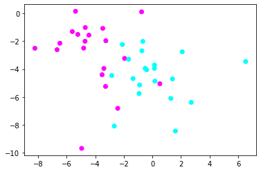

```
x: [-8.22, 6.52]
y: [-9.69, 0.14]
```

```python
# 生成数据
import numpy as np
import matplotlib.pyplot as plt

# 生成数据
from sklearn.datasets import make_blobs
# 40个点，2个中心，标准差2
X, y=make_blobs(n_samples=40, centers=2, random_state=50, cluster_std=2)
print(X.shape) #数据是40行，2个特征(x和y)

# 散点图
plt.scatter(X[:,0], X[:,1], c=y, cmap=plt.cm.cool)
plt.show()

# 2个特征的范围
print("x: [{:0.2f}, {:0.2f}]".format( X[:,0].min(), X[:,0].max()) )
print("y: [{:0.2f}, {:0.2f}]".format( X[:,1].min(), X[:,1].max()) )
```

## StandardScaler: Z 标准化

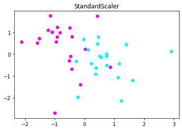

```
x: [-2.11, 2.92]
y: [-2.71, 1.76]
```

```python
from sklearn.preprocessing import StandardScaler
# 预处理
X_1=StandardScaler().fit_transform(X)

# 散点图
plt.scatter(X_1[:,0], X_1[:,1], c=y, cmap=plt.cm.cool)
plt.title("StandardScaler")
plt.show()

# 2个特征的范围
print("x: [{:0.2f}, {:0.2f}]".format( X_1[:,0].min(), X_1[:,0].max()) )
print("y: [{:0.2f}, {:0.2f}]".format( X_1[:,1].min(), X_1[:,1].max()) )

# 可见点之间的相对位置不变，但是x和y的极值都缩小到0附近了
# Z标注化后的数据符合 标准正态分布 N(0,1)
```

help(StandardScaler)

- Standardize features by removing the mean and scaling to unit variance.
- The standard score of a sample `x` is calculated as: z = (x - u) / s
  - where `u` is the mean of the training samples or zero if `with_mean=False`,
  - and `s` is the standard deviation of the training samples or one if `with_std=False`.

## MinMaxScaler: 极值标准化[0, 1]

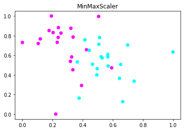

```
x: [0.00, 1.00]
y: [0.00, 1.00]
```

```python
from sklearn.preprocessing import MinMaxScaler
# 预处理
X_2=MinMaxScaler().fit_transform(X)

# 散点图
plt.scatter(X_2[:,0], X_2[:,1], c=y, cmap=plt.cm.cool)
plt.title("MinMaxScaler")
plt.show()

# 2个特征的范围
print("x: [{:0.2f}, {:0.2f}]".format( X_2[:,0].min(), X_2[:,0].max()) )
print("y: [{:0.2f}, {:0.2f}]".format( X_2[:,1].min(), X_2[:,1].max()) )

# x = (x - min)/(max - min) 都在[0, 1]之间
```

## RobustScaler: (x-median)/IQR

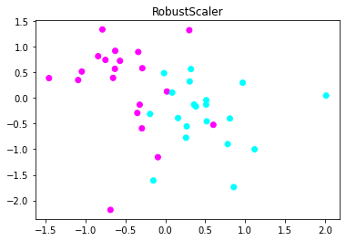

```
x: [-1.46, 2.02]
y: [-2.18, 1.33]
```

```python
from sklearn.preprocessing import RobustScaler
# 预处理
X_3=RobustScaler().fit_transform(X)

# 散点图
plt.scatter(X_3[:,0], X_3[:,1], c=y, cmap=plt.cm.cool)
plt.title("RobustScaler")
plt.show()

# 2个特征的范围
print("x: [{:0.2f}, {:0.2f}]".format( X_3[:,0].min(), X_3[:,0].max()) )
print("y: [{:0.2f}, {:0.2f}]".format( X_3[:,1].min(), X_3[:,1].max()) )

# 使用中位数和四分位数进行转换，而不是使用均值和方差。
# 能去掉异常值 outlier。
```

help(RobustScaler)

- Scale features using statistics that are robust to outliers.
- This Scaler removes the median and scales the data according to the quantile range (defaults to IQR: Interquartile Range).
  - The IQR is the range between the 1st quartile (25th quantile) and the 3rd quartile (75th quantile).

## Normalizer: 面目全非的转换

将所有样本的特征向量转化为欧几里得距离为1.

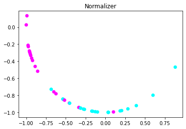

```
x: [-1.00, 0.88]
y: [-1.00, 0.13]
```

```python
from sklearn.preprocessing import Normalizer
# 预处理
X_4=Normalizer().fit_transform(X)

# 散点图
plt.scatter(X_4[:,0], X_4[:,1], c=y, cmap=plt.cm.cool)
plt.title("Normalizer")
plt.show()

# 2个特征的范围
print("x: [{:0.2f}, {:0.2f}]".format( X_4[:,0].min(), X_4[:,0].max()) )
print("y: [{:0.2f}, {:0.2f}]".format( X_4[:,1].min(), X_4[:,1].max()) )
```

## sklearn 中其他的预处理方法

```python
# 用到了再查文档
import sklearn.preprocessing
dir(sklearn.preprocessing)
```

```
['Binarizer',
 'FunctionTransformer',
 'KBinsDiscretizer',
 'KernelCenterer',
 'LabelBinarizer',
 'LabelEncoder',
 'MaxAbsScaler',
 'MinMaxScaler',
 'MultiLabelBinarizer',
 'Normalizer',
 'OneHotEncoder',
 'OrdinalEncoder',
 'PolynomialFeatures',
 'PowerTransformer',
 'QuantileTransformer',
 'RobustScaler',
 'SplineTransformer',
 'StandardScaler',
 '__all__',
 '__builtins__',
 '__cached__',
 '__doc__',
 '__file__',
 '__loader__',
 '__name__',
 '__package__',
 '__path__',
 '__spec__',
 '_csr_polynomial_expansion',
 '_data',
 '_discretization',
 '_encoders',
 '_function_transformer',
 '_label',
 '_polynomial',
 'add_dummy_feature',
 'binarize',
 'label_binarize',
 'maxabs_scale',
 'minmax_scale',
 'normalize',
 'power_transform',
 'quantile_transform',
 'robust_scale',
 'scale']
```

## 通过预处理提高模型的准确率

```python
from sklearn.datasets import load_wine
from sklearn.neural_network import MLPClassifier
from sklearn.model_selection import train_test_split

wine=load_wine()
X_train, X_test, y_train, y_test = train_test_split(wine.data, wine.target, random_state=62)

print(X_train.shape, X_test.shape)
```

```
(133, 13) (45, 13)
```

```python
# 训练神经网络
mlp=MLPClassifier(hidden_layer_sizes=[100,100], max_iter=700, random_state=62)
mlp.fit(X_train, y_train)

# 打分
print("training set:{:0.3f}".format( mlp.score(X_train, y_train)) )
print("tesing set:{:0.3f}".format( mlp.score(X_test, y_test)) )
```

```
training set:0.992
tesing set:0.933
```

```python
# 数据预处理
scaler=MinMaxScaler()
scaler.fit(X_train)
X_train_scaled=scaler.transform(X_train)
X_test_scaled=scaler.transform(X_test)

# 训练
mlp.fit(X_train_scaled, y_train)

# 打分
print("training set:{:0.3f}".format( mlp.score(X_train_scaled, y_train)) )
print("tesing set:{:0.3f}".format( mlp.score(X_test_scaled, y_test)) )
# 惊呆了！ 完全正确。

# 记住数据预处理的顺序：先拟合原始train数据，再转换原始的train和test数据。
# 而不能 拟合原始test数据，再去转换test数据，这样就失去了数据转换的意义了。
```

```
training set:1.000
tesing set:1.000
```

# 降维

## PCA 降维后可视化

```python
# 载入数据
from sklearn.datasets import load_wine
wine=load_wine()

# 载入预处理
from sklearn.preprocessing import StandardScaler
scaler=StandardScaler()
X=wine.data
y=wine.target
X_scaled = scaler.fit_transform(X)
print(X_scaled.shape) # 13个特征
```

```
(178, 13)
```

```python
# 为了可视化最显著的特征方向，我们需要做PCA
from sklearn.decomposition import PCA
# 设置主成分数量为2
pca=PCA(n_components=2)
pca.fit(X_scaled) #拟合
X_pca=pca.transform(X_scaled) #转换
print(X_pca.shape) # 2个主成分(特征组合)
```

```
(178, 2)
```

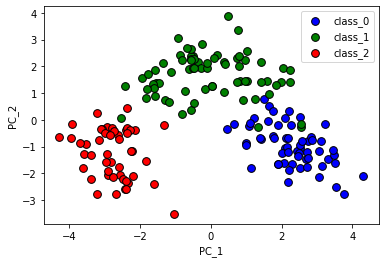

```python
# 可视化
import numpy as np
import matplotlib.pyplot as plt

# 将三个分类中的主成分提取出来
X0=X_pca[wine.target==0]
X1=X_pca[wine.target==1]
X2=X_pca[wine.target==2]

# 绘制散点图
plt.scatter(X0[:,0], X0[:,1], c='b', s=60, edgecolor='k')
plt.scatter(X1[:,0], X1[:,1], c='g', s=60, edgecolor='k')
plt.scatter(X2[:,0], X2[:,1], c='r', s=60, edgecolor='k')

plt.legend(wine.target_names, loc="best")
plt.xlabel("PC_1")
plt.ylabel("PC_2")
plt.show()

# 将数据降到2维，从图片中差不多能看到3类的分界线。
```

## 原始特征与PCA主成分之间的关系

从数学上讲，需要先理解内积和投影。本文略。

本文只直观绘图。

```python
print(pca.components_.shape)

pca.components_
# 一个主成分，就等于原始特征前面乘以这个系数。
# 系数使正，就是原始特征和PC正相关；为负，就是和PC负相关。
```

```
(2, 13)
```

```
array([[ 0.1443294 , -0.24518758, -0.00205106, -0.23932041,  0.14199204,
         0.39466085,  0.4229343 , -0.2985331 ,  0.31342949, -0.0886167 ,
         0.29671456,  0.37616741,  0.28675223],
       [-0.48365155, -0.22493093, -0.31606881,  0.0105905 , -0.299634  ,
        -0.06503951,  0.00335981, -0.02877949, -0.03930172, -0.52999567,
         0.27923515,  0.16449619, -0.36490283]])
```

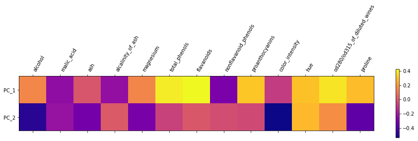

```python
# 使用主成分绘制热图
# plt.figure(figsize=(2,1))
plt.matshow(pca.components_, cmap="plasma")

# y轴作为主成分数
plt.yticks([0,1], ["PC_1", "PC_2"])
plt.colorbar()
# x轴为原始特征数量
plt.xticks( range(len(wine.feature_names)), wine.feature_names, rotation=60, ha="left" )
plt.show()
```

```python
# 每个主成分解释的变异性百分比
pca.explained_variance_ratio_
```

```
array([0.36198848, 0.1920749 ])
```

help(PCA)

# 特征提取

使用 LFW(Labeled Faces in the Wild) 人脸识别数据集。

- http://vis-www.cs.umass.edu/lfw/

## 载入 LFW 人脸识别数据集

```python
# 导入数据集获取工具
from sklearn.datasets import fetch_lfw_people
# 载入人脸数据集
faces=fetch_lfw_people(min_faces_per_person=20, resize=0.8)
image_shape = faces.images[0].shape
image_shape
```

```
(100, 75)
```

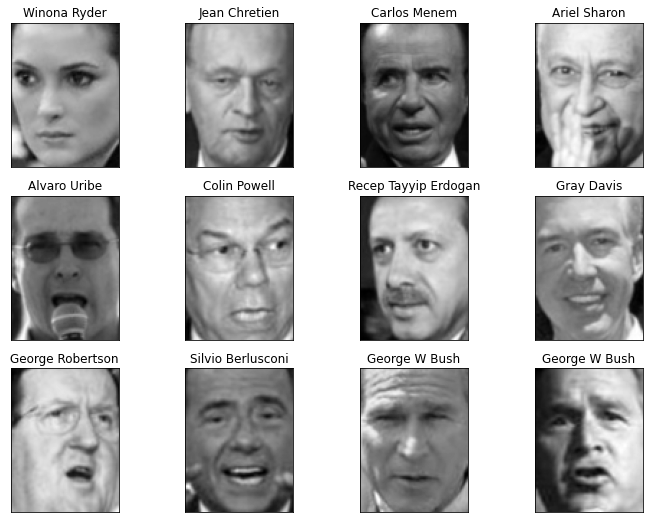

```python
# 显示照片
import numpy as np
import matplotlib.pyplot as plt

fig, axes = plt.subplots(3, 4, figsize=(12,9),
                         subplot_kw={"xticks":(), "yticks":()})
for target, image, ax in zip(faces.target, faces.images, axes.ravel()):
    ax.imshow(image, cmap=plt.cm.gray)
    ax.set_title(faces.target_names[target])
plt.show()
```

```python
print(faces.target.min(), faces.target.max() ) #共62个人
```

```
0 61
```

## 预测人脸

```python
# 对数据拆分
import time
start=time.time()

from sklearn.model_selection import train_test_split
X_train, X_test, y_train, y_test = train_test_split(faces.data/255, faces.target, random_state=0)

# 导入神经网络
from sklearn.neural_network import MLPClassifier
mlp=MLPClassifier(hidden_layer_sizes=[100,100], random_state=0, max_iter=400)
mlp.fit(X_train, y_train)

print("time:{:0.2f}".format(time.time()-start, "s") )

# 打分
print("training set:{:0.3f}".format( mlp.score(X_train, y_train)) )
print("tesing set:{:0.3f}".format( mlp.score(X_test, y_test)) )

# 耗时: 60s
# 测试集记住了一半多一点。能在一分钟内记住 36/62 个人脸，也算很厉害了。
```

```
time:60.08
training set:0.986
tesing set:0.583
```

## 白化 data whiten

所谓白化，就是降低冗余性，消除相邻像素的相关性，且使所有特征具有相同的方差。

```python
from sklearn.decomposition import PCA

# 使用 PCA 的白化功能处理人脸
pca=PCA(whiten=True, n_components=0.9, random_state=0)
pca.fit(X_train)
X_train_whiten=pca.transform(X_train)
X_test_whiten = pca.transform(X_test)
# (2267, 105) (756, 105)

# 维度
print( X_train.shape, X_test.shape ) #7500 列
print( X_train_whiten.shape, X_test_whiten.shape ) #105 列
```

```
(2267, 7500) (756, 7500)
(2267, 105) (756, 105)
```

```python
# 导入神经网络
from sklearn.neural_network import MLPClassifier
mlp=MLPClassifier(hidden_layer_sizes=[100,100], random_state=0, max_iter=400)
mlp.fit(X_train_whiten, y_train)

# 打分
print("training set:{:0.3f}".format( mlp.score(X_train_whiten, y_train)) )
print("tesing set:{:0.3f}".format( mlp.score(X_test_whiten, y_test)) )
# 训练集满分，测试集打分比白化前又降了。

# 真是玄学。
```

```
training set:1.000
tesing set:0.571
```

## NMF 非负矩阵分解用于特征提取

矩阵分解，就是把一个矩阵写成n个矩阵的连乘。

- 非负矩阵分解，就是原始矩阵中所有的数值必须大于或等于0，当然分解后的矩阵中的数据也是大于或等于0的。
- 直观解释：一堆特征值混乱无序的堆放在空间中，NMF可以看成是从原点(0,0)引出一个(或几个)vector，
  - 用这些vector尽可能的把原始特征值的信息表达出来。

与PCA的区别：

- 如果我们降低NMF的成分数量，它会重新生成新的成分，而新的成分与原来的成分是完全不同的。
- NMF中的成分是没有顺序的，这点和PCA也有所不同。

```python
# 使用 NMF 对LFW人脸数据集进行特征提取，再重新训练神经网络，看看模型的正确率是否变化
import time
start=time.time()

# 导入 NMF
from sklearn.decomposition import NMF
# 使用NMF处理数据: 很慢 15:42->15:
nmf = NMF(n_components=105, max_iter=400, random_state=62).fit(X_train) #默认 max_iter=200
X_train_nmf = nmf.transform(X_train)
X_test_nmf=nmf.transform(X_test)
print("time:{:0.2f}".format(time.time()-start, "s") )

# 打印NMF处理后的数据形状
print("shpe before NMF: ", X_train.shape)
print("shpe after NMF: ", X_train_nmf.shape)
```

```
time:80.86
shpe before NMF:  (2267, 7500)
shpe after NMF:  (2267, 105)
```

```python
# 使用 NMF 分解后的矩阵 训练神经网络
mlp.fit(X_train_nmf, y_train)

# 打分
print("training set:{:0.3f}".format( mlp.score(X_train_nmf, y_train)) )
print("tesing set:{:0.3f}".format( mlp.score(X_test_nmf, y_test)) )
# 打分更低了！时间比PCA长，效果比PCA差。
```

```
training set:0.991
tesing set:0.558
```

# 聚类

## k-means 聚类

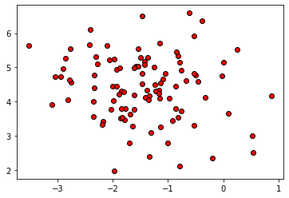

```python
import numpy as np
import matplotlib.pyplot as plt

from sklearn.datasets import make_blobs
blobs=make_blobs(random_state=1, centers=1)
X_blobs=blobs[0]

# 可视化
plt.scatter(X_blobs[:,0], X_blobs[:,1], c='r', edgecolor='k')
plt.show()
# 目测确实无差别
```

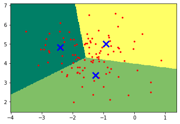

```python
# 导入 KMeans 工具
from sklearn.cluster import KMeans
kmeans = KMeans(n_clusters=3, random_state=7)
kmeans.fit(X_blobs)

# 可视化
x_min, x_max=X_blobs[:,0].min()-0.5, X_blobs[:,0].max()+0.5
y_min, y_max=X_blobs[:,1].min()-0.5, X_blobs[:,1].max()+0.5
xx, yy = np.meshgrid(np.arange(x_min, x_max, 0.02),
                    np.arange(y_min, y_max, 0.02))
Z=kmeans.predict(np.c_[xx.ravel(), yy.ravel()])
Z=Z.reshape(xx.shape)

plt.figure(1)
plt.clf()
plt.imshow(Z, interpolation="nearest",
          extent=(xx.min(), xx.max(), yy.min(), yy.max()),
          cmap=plt.cm.summer,
          aspect='auto', origin='lower')
plt.plot(X_blobs[:,0], X_blobs[:,1], 'r.', markersize=5)

# 用蓝色叉号代表聚类中心
centroids = kmeans.cluster_centers_
plt.scatter(centroids[:,0], centroids[:,1],
           marker='x', s=150, linewidths=3, color='b', zorder=10)
plt.xlim(x_min, x_max)
plt.ylim(y_min, y_max)
plt.xticks()
plt.yticks()
plt.show()
```

```python
# 打印 KMeans 进行聚类的标签
print("K均值的聚类标签:\n{}".format(kmeans.labels_))

# k-means 的优点是简单；
# 缺点是它认为每个点到聚类中心的方向都是同等重要的，对于“形状”复杂的数据集，k均值就表现很差。
```

```
K均值的聚类标签:
[1 1 0 2 2 2 1 1 0 2 1 2 1 0 1 2 2 1 0 0 2 0 1 1 1 1 2 1 1 1 0 0 1 1 2 0 2
 0 1 0 2 1 0 0 2 2 2 1 0 1 0 1 2 0 2 2 0 2 2 1 2 0 2 1 0 2 0 0 1 2 2 1 2 2
 2 1 2 1 1 0 2 0 2 2 0 1 2 1 0 0 2 1 0 0 2 2 1 2 2 1]
```

## 凝聚聚类算法

简单说，就是最近的聚类，然后剩下的最近的再聚类，一直到最后成为一类。

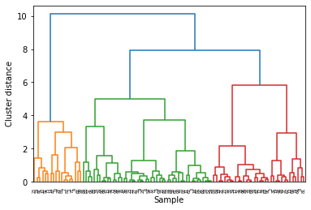

```python
from scipy.cluster.hierarchy import dendrogram, ward

# 使用连线的方式进行可视化
linkage=ward(X_blobs)
dendrogram(linkage)
ax=plt.gca() #这个有啥用？

plt.xlabel("Sample")
plt.ylabel("Cluster distance")
plt.show()

# 感觉就是R中的层次聚类。
# 也不能处理“形状”复杂的数据集。
```

## DBSCAN 算法

全称是“基于密度的有噪声应用空间聚类”(Density-based spatial clustering of applications with noise)

- 通过对特征空间内的密度进行检测，密度大的地方认为是一类，密度小的地方认为是一个分界线。
- 所以一开始不需要指定 聚类数量 n_clusters.

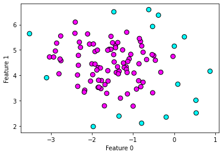

```python
from sklearn.cluster import DBSCAN
db=DBSCAN()

# 拟合
clusters=db.fit_predict(X_blobs)

#可视化
plt.scatter(X_blobs[:,0], X_blobs[:,1], c=clusters, cmap=plt.cm.cool, s=60, edgecolor='k')

plt.xlabel("Feature 0")
plt.ylabel("Feature 1")
plt.show()
```

```python
# 打印聚类个数
print("聚类标签:\n{}".format(clusters))

# 为什么会有-1？原来 DBSCAN 认为-1是噪声。
# 中间一团密度比较大，归为一类；周围浅色的不属于任何一类，放入噪声类。
```

```
聚类标签:
[-1  0 -1  0 -1  0  0  0  0  0  0  0  0  0 -1  0  0  0  0  0  0  0  0  0
  0 -1  0  0 -1  0  0  0  0  0  0  0  0  0  0  0  0  0  0  0  0  0  0 -1
  0  0  0  0  0  0  0  0  0 -1  0  0  0  0  0  0 -1  0  0  0  0  0  0  0
  0  0 -1 -1  0  0  0  0 -1  0  0 -1  0  0 -1  0  0  0  0  0  0  0  0 -1
  0  0  0 -1]
```

### DBSCAN 重要的参数

DBSCAN 重要的参数:

- eps: 指定划入同一类的样本距离又多远，eps越大，聚类覆盖的数据点越多；默认0.5；
- min_samples: 某个数据点周围，被看成是聚类核心点的个数；越大则核心数据点越少，噪声越多；越小噪声越小；默认2.

help(DBSCAN)

eps : float, default=0.5

- The maximum distance between two samples for one to be considered as in the neighborhood of the other.
- This is not a maximum bound on the distances of points within a cluster.
- This is the most important DBSCAN parameter to choose appropriately for your data set and distance function.

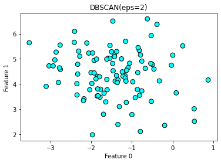

```python
# 调整 eps 参数 0.5->2
from sklearn.cluster import DBSCAN
db_1=DBSCAN(eps=2)
# 拟合
clusters_1=db_1.fit_predict(X_blobs)

#可视化
plt.scatter(X_blobs[:,0], X_blobs[:,1], c=clusters_1, cmap=plt.cm.cool, s=60, edgecolor='k')

plt.xlabel("Feature 0")
plt.ylabel("Feature 1")
plt.title("DBSCAN(eps=2)")
plt.show()
# 只有一类，没有噪音了
```

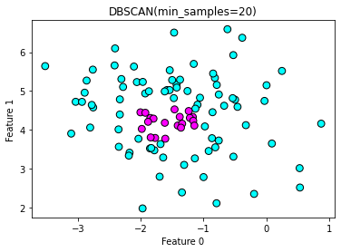

```python
# 调整 min_samples 参数 2->20
from sklearn.cluster import DBSCAN
db_2=DBSCAN(min_samples=20)
# 拟合
clusters_2=db_2.fit_predict(X_blobs)

#可视化
plt.scatter(X_blobs[:,0], X_blobs[:,1], c=clusters_2, cmap=plt.cm.cool, s=60, edgecolor='k')

plt.xlabel("Feature 0")
plt.ylabel("Feature 1")
plt.title("DBSCAN(min_samples=20)")
plt.show()
# min_samples 调大，噪音点变多。
```

实际使用时，先使用 MinMaxScaler 或 StandardScaler 进行预处理，DBSCAN算法的表现会更好。